# Exercícios Aula 6 - Visualização de dados

Beatriz Milz

17/04/2020

```r
library(nycflights13)
library(tidyverse)
library(knitr)
library(ggthemes)
```

## Exercício 1: Gráficos de uma Variável

1. Prepare um gráfico de barras mostrando o número de voos por mês.

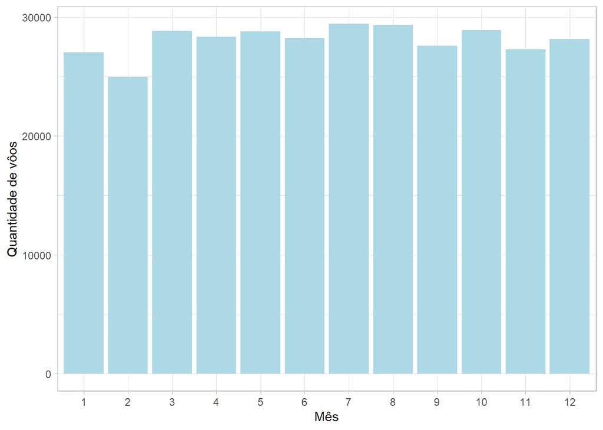

```r
flights %>%
  mutate(month = as_factor(month)) %>%
  ggplot() +
  geom_bar(aes(x = month), fill = "lightblue") +
  theme_light()+
  labs(x = "Mês", y = "Quantidade de vôos")
```

2. Prepare um gráfico de barras mostrando o número de voos por companhia aérea (carrier) para o aeroporto de origem JFK.

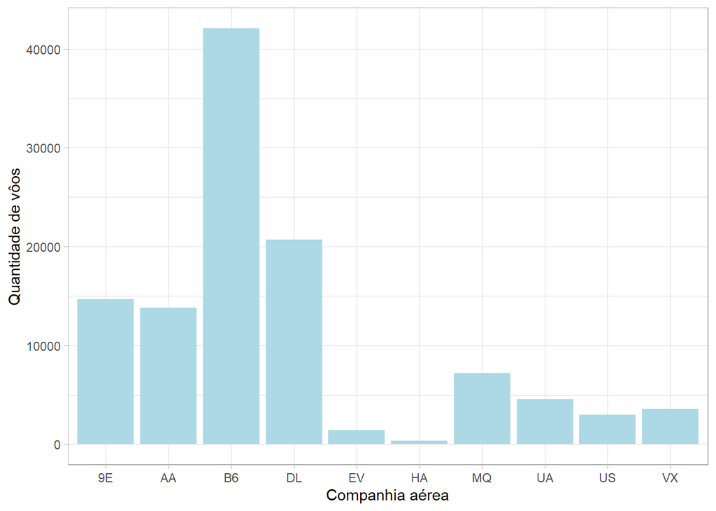

```r
flights %>%
filter(origin == "JFK") %>%
  ggplot() +
  geom_bar(aes(x = carrier), fill = "lightblue") +
  theme_light()+
  labs(x = "Companhia aérea", y = "Quantidade de vôos")
```

3. Prepare uma histograma mostrando a distribuição de número de voos por hora de partida (dep_time) para voos entre EWR e SFO (San Francisco).

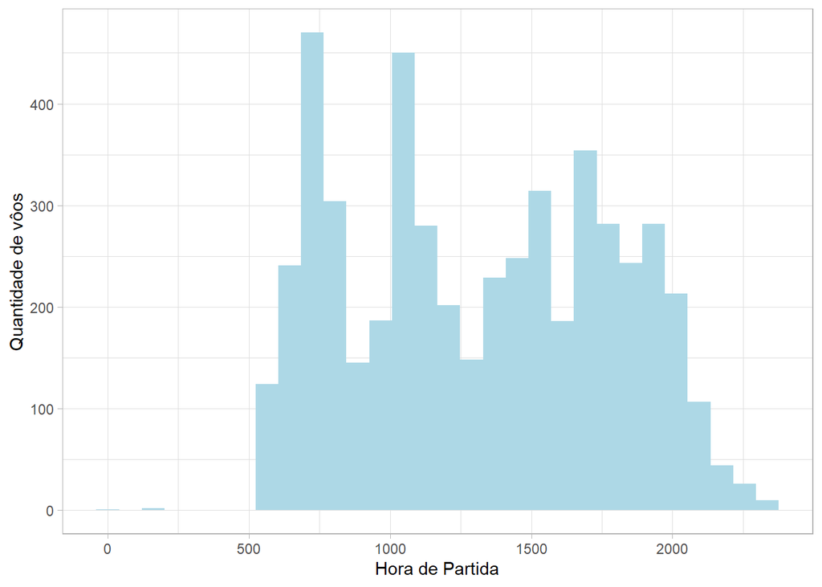

```r
flights %>%
filter(origin == "EWR" & dest == "SFO") %>%
  ggplot() +
  geom_histogram(aes(x = dep_time), fill = "lightblue") +
  theme_light()+
  labs(x = "Hora de Partida", y = "Quantidade de vôos")
```

4. Prepare um gráfico de densidade mostrando a distribuição de duração (air_time) para voos entre JFK e LAX (Los Angeles).

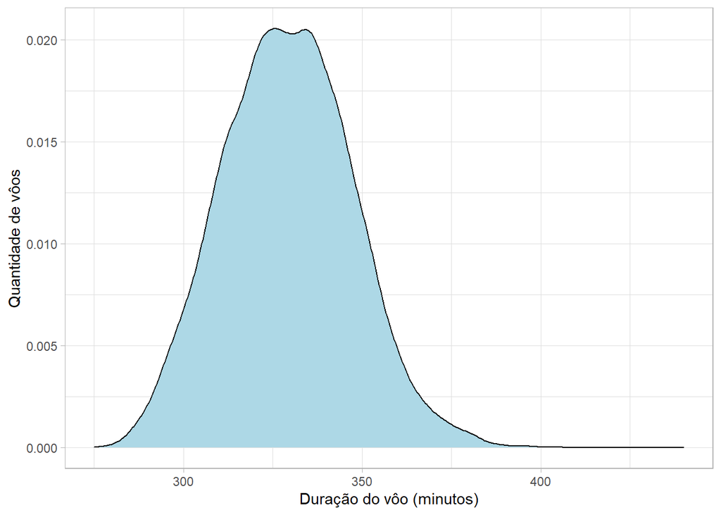

```r
flights %>%
filter(origin == "JFK" & dest == "LAX") %>%
  ggplot() +
  geom_density(aes(x = air_time), fill = "lightblue") +
  theme_light()+
  labs(x = "Duração do vôo (minutos)", y = "Quantidade de vôos")
```

## Exercício 2: Gráficos de duas Variáveis

1. Prepare um gráfico de densidade mostrando a distribuição de hora de partida de voos entre EWR e BOS (Boston) por companhia aérea (carrier).

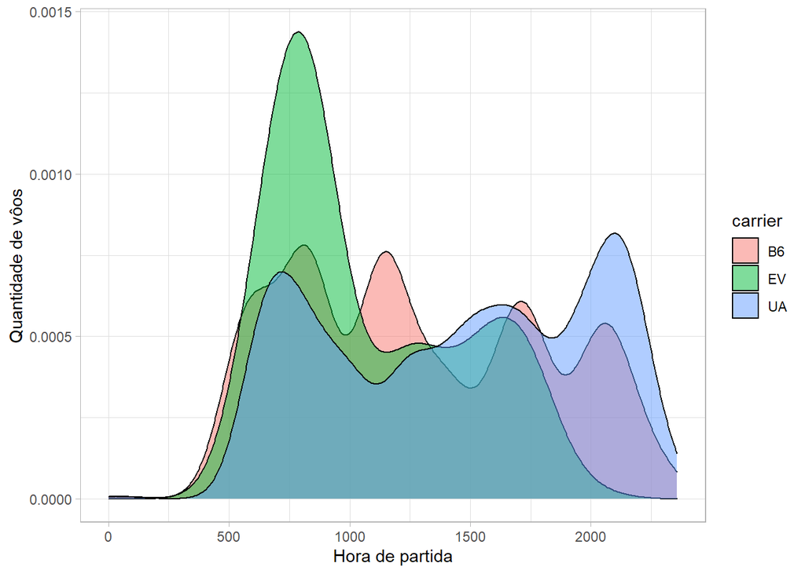

```r
flights %>%
filter(origin == "EWR" & dest == "BOS") %>%
  ggplot() +
  geom_density(aes(x = dep_time, fill = carrier), alpha = 0.5) +
  theme_light()+
  labs(x = "Hora de partida", y = "Quantidade de vôos")
```

2. Prepare um gráfico de colunas/barras (geom_col) mostrando a duração média (air_time) de voos de cada companhia aérea.

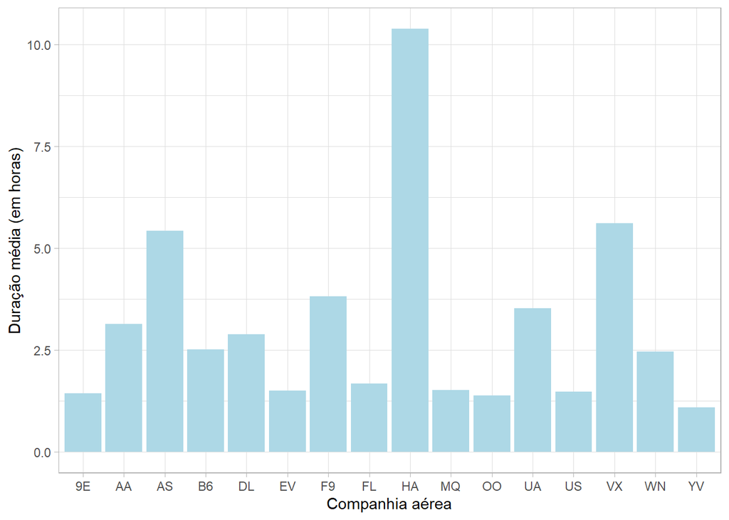

```r
flights %>%
  group_by(carrier) %>%
  summarise(mean_minutos = mean(air_time, na.rm = TRUE),
            mean_horas = mean_minutos/60) %>%
  ungroup %>%
  ggplot()+
  geom_col(aes(x = carrier, y = mean_horas), fill = "lightblue") +
  theme_light()+
  labs(x = "Companhia aérea", y = "Duração média (em horas)")
```

3. Prepare um gráfico de pontos mostrando a relação entre o atraso na partida (dep_delay) e o atraso na chegada (arr_delay) para os voos de JFK a MIA (Miama).

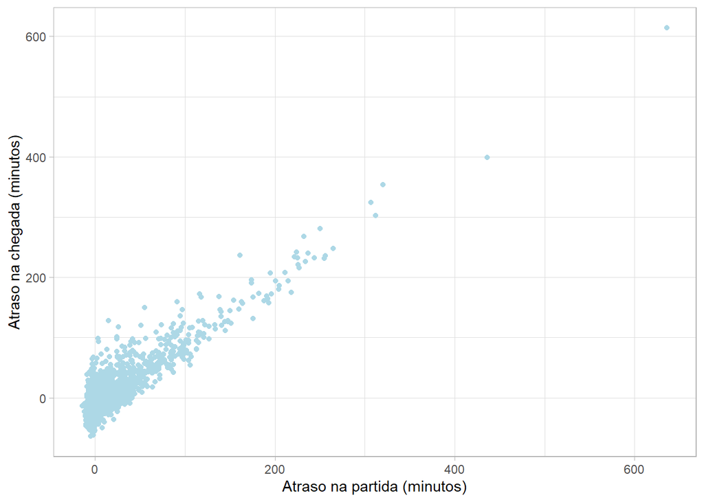

```r
flights %>%
  filter(origin == "JFK" & dest == "MIA") %>%
  ggplot()+
  geom_point(aes(x = dep_delay, y = arr_delay), color = "lightblue") +
  theme_light()+
  labs(x = "Atraso na partida (minutos)", y = "Atraso na chegada (minutos)")
```

4. Prepare um gráfico de pontos mostrando a relação entre a duração (air_time) média e o atraso média (dep_delay) de cada companhia aérea.

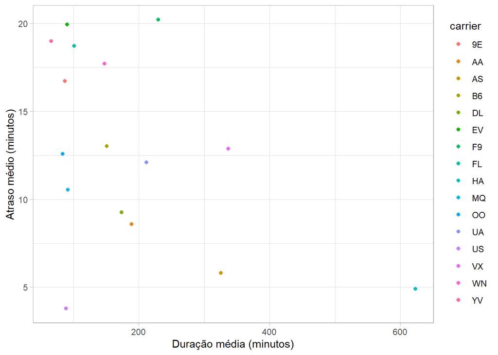

```r
flights %>%
group_by(carrier) %>%
  summarise(duracao_media = mean(air_time, na.rm = TRUE),
            atraso_media = mean(dep_delay, na.rm = TRUE)
            ) %>%
  ggplot()+
  geom_point(aes(x = duracao_media, y = atraso_media, color = carrier)) +
  theme_light()+
  labs(x = "Duração média (minutos)", y = "Atraso médio (minutos)")
```

5. Adicione uma linha de tendência/regressão linear no gráfico da questão 4.

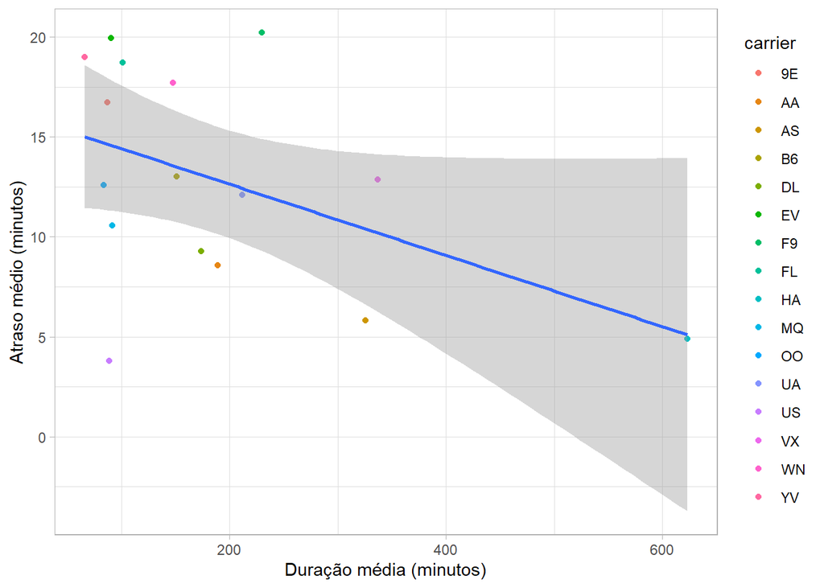

```r
flights %>%
group_by(carrier) %>%
  summarise(duracao_media = mean(air_time, na.rm = TRUE),
            atraso_media = mean(dep_delay, na.rm = TRUE)
            ) %>%
  ggplot()+
  geom_point(aes(x = duracao_media, y = atraso_media, color = carrier)) +

  geom_smooth(aes(x = duracao_media, y = atraso_media), method = "lm")+
  theme_light()+
  labs(x = "Duração média (minutos)", y = "Atraso médio (minutos)")
```

## Exercício 3: Gráficos Avançados

1. Começando com o mesmo gráfico de Exercício 2 Q3, prepare o gráfico de pontos mostrando a relação entre o atraso na partida (dep_delay) e o atraso na chegada (arr_delay) para os voos de JFK a MIA (Miama). Colora os pontos de acordo com a companhia aérea, e adicione títulos bem formatos nos eixos e para o gráfico inteiro.

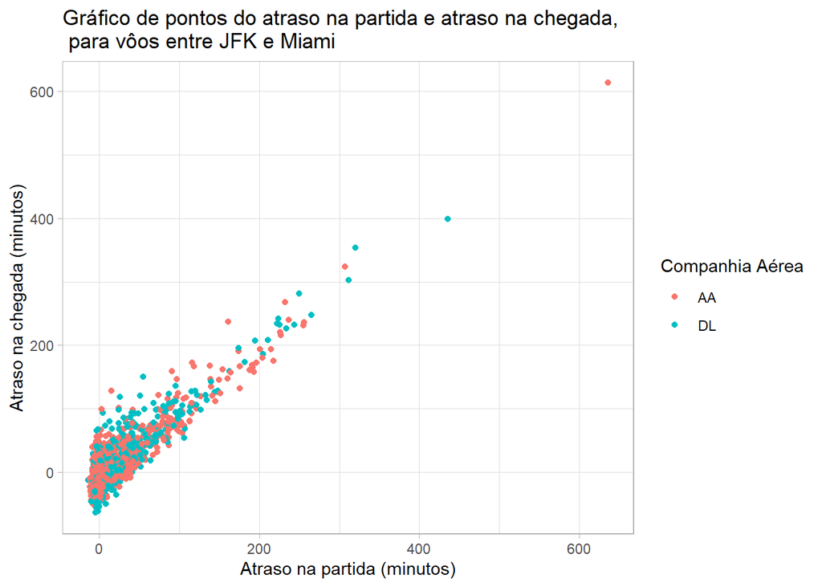

```r
flights %>%
  filter(origin == "JFK" & dest == "MIA") %>%
  ggplot()+
  geom_point(aes(x = dep_delay, y = arr_delay, color = carrier)) +
  theme_light()+
  labs(x = "Atraso na partida (minutos)", y = "Atraso na chegada (minutos)",
       color = "Companhia Aérea", title = "Gráfico de pontos do atraso na partida e atraso na chegada, \n para vôos entre JFK e Miami")
```

2. Ajuste o seu gráfico de questão 1 para que o cor do ponto reflete uma variável contínua, a hora de partida (dep_time), usando uma escala de cores apropriada.

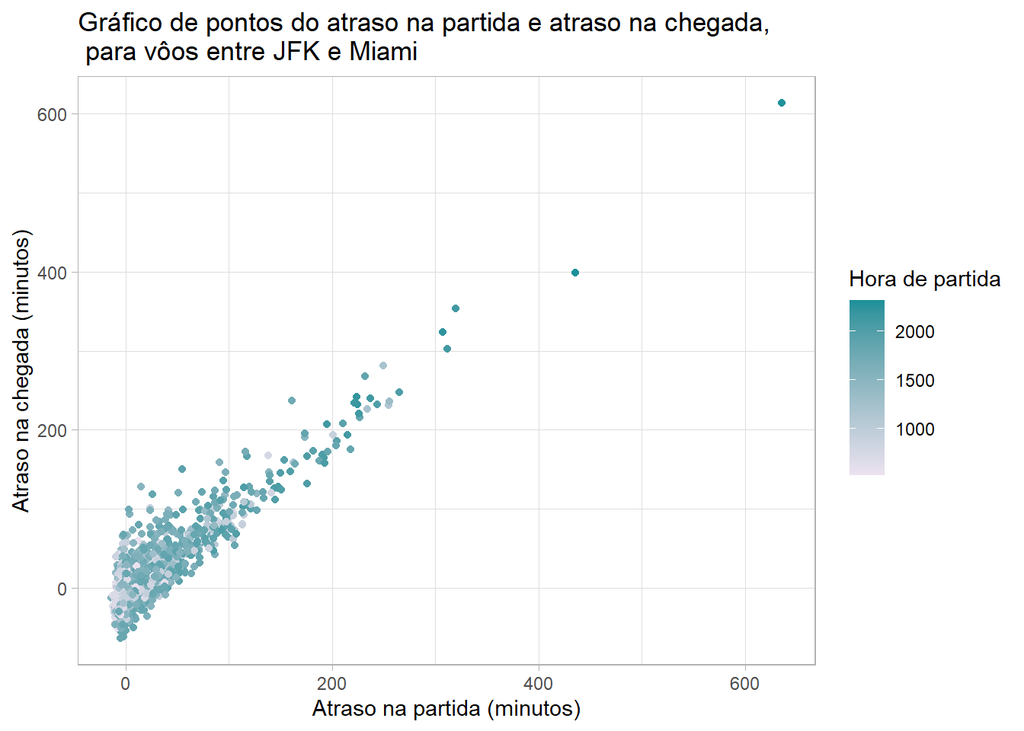

```r
flights %>%
  filter(origin == "JFK" & dest == "MIA") %>%
  ggplot() +
  geom_point(aes(x = dep_delay, y = arr_delay, color = dep_time)) +
  theme_light() +
  scale_color_gradient(low = "#ece2f0", high = "#1c9099")   +
  labs(
    x = "Atraso na partida (minutos)",
    y = "Atraso na chegada (minutos)",
    color = "Hora de partida",
    title = "Gráfico de pontos do atraso na partida e atraso na chegada, \n para vôos entre JFK e Miami"
  )
```

3. Prepare um gráfico de linhas mostrando a distância de viagem de todos os voos por mês, com uma linha para cada aeroporto de origem. Aplique uma escala de cores apropriada.

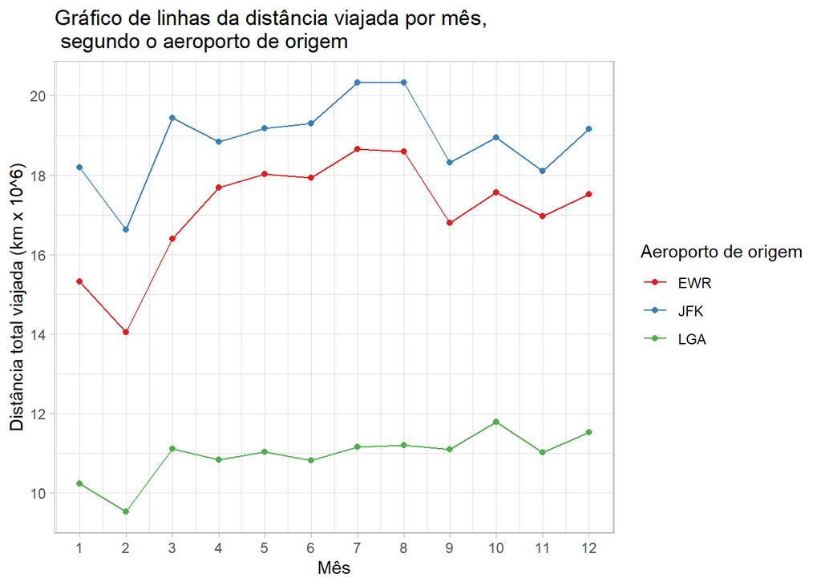

```r
flights %>%
  group_by(origin, month) %>%
  summarise(total_dist_miles = sum(distance, na.rm = T)) %>%
  mutate(total_dist_km = total_dist_miles/0.62137,
         total_dist_km_10_6 = total_dist_km/1000000
         ) %>%

  ggplot() +
  geom_line(aes(x = month, y = total_dist_km_10_6, color = origin)) +
  geom_point(aes(x = month, y = total_dist_km_10_6, color = origin)) +
  scale_color_brewer(palette = "Set1")+

theme_light() +

  labs(
    x = "Mês",
    y = "Distância total viajada (km x 10^6)",
    color = "Aeroporto de origem",
   title = "Gráfico de linhas da distância viajada por mês, \n segundo o aeroporto de origem"
  )+
    scale_x_continuous(breaks=seq(1,12,1))+
    scale_y_continuous(breaks=seq(0,50,2))
```

4. Prepare vários gráficos numa grade, cada um mostrando a relação entre a hora de partida (hour) e o atraso média de partida em um aeroporto de origem para uma companhia aérea.

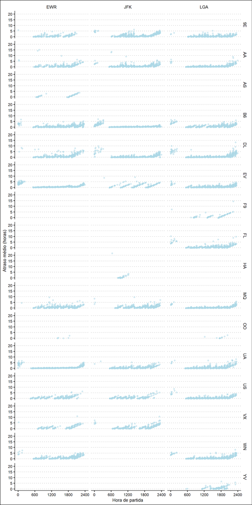

```r
flights %>%
  group_by(origin, carrier, dep_time) %>%
  summarise(atraso_medio = mean(dep_delay, na.rm = T)) %>%
  mutate(atraso_medio_horas = atraso_medio / 60) %>%
  ggplot() +
  geom_point(aes(x = dep_time, y = atraso_medio_horas), color = "lightblue", alpha = 0.5) +
               facet_grid(carrier ~ origin)+
  theme_clean() +
  labs(x = "Hora de partida",
       y = "Atraso médio (horas)")+
  scale_x_continuous(breaks=seq(0,2400,600))
```